# Demo 3 | Drawing the U.S. Hu Line

Peter Kedron

2026-09-22

# 1. Introduction

## 1.1 The Lorenz Curve

The Lorenz curve (1905) provides a visual depiction of inequality; it consists of a plot of cumulative values on both the vertical and horizontal axes. In its most common application, namely to income inequality, incomes are first ranked from lowest to highest and then cumulative population is plotted on the x-axis and then cumulative income on the *y*-axis. The degree to which the curve bows away from the 45° line is a measure of inequality. The Lorenz curve can also be used in the context of population distribution, where regional populations are first ordered in terms of increasing population density, and then cumulative land area is plotted on the horizontal axis, against cumulative population on the vertical axis.

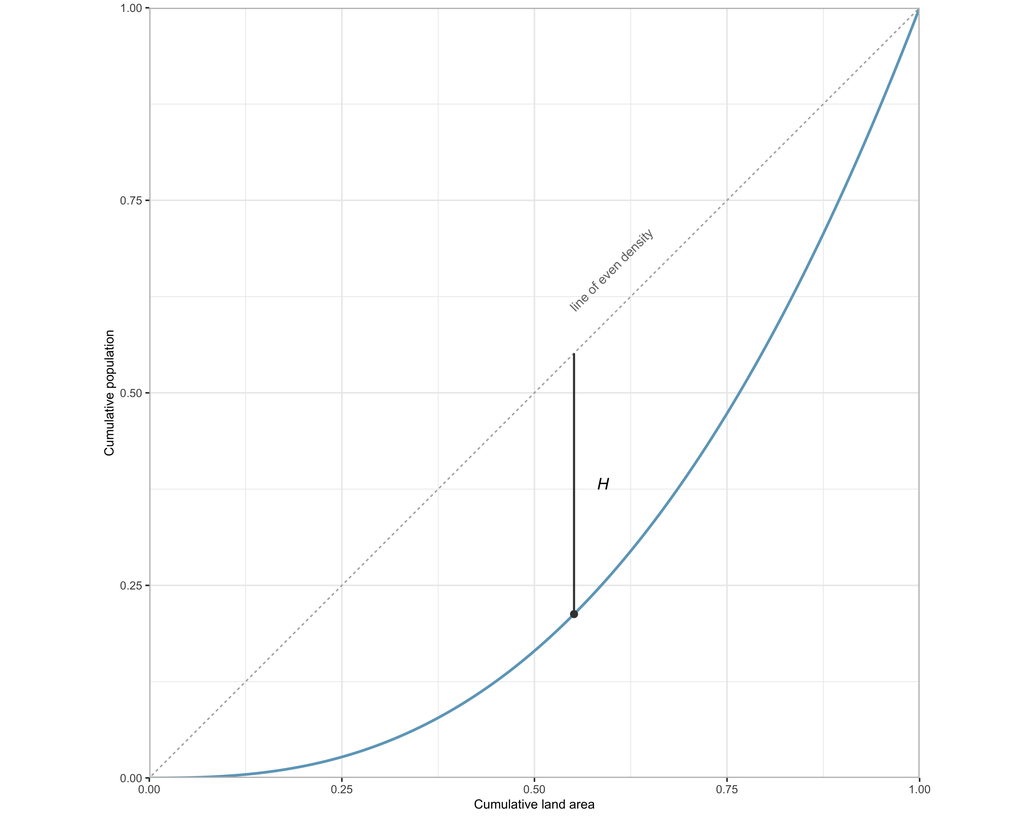

```r
# A generic Lorenz curve, drawn to illustrate the construction rather than to
# describe any particular dataset. Regions are ordered from lowest to highest
# population density, so the curve falls below the 45 degree line.

lorenz_demo <- tibble(
  cum_area = seq(0, 1, length.out = 400),
  cum_pop  = cum_area^2.6)  # curvature is arbitrary; larger is more unequal

# the Hoover index is the largest vertical gap between the curve and the line
h_demo <- lorenz_demo %>%
  mutate(gap = cum_area - cum_pop) %>%
  slice_max(gap, n = 1, with_ties = FALSE)
ggplot(lorenz_demo, aes(cum_area, cum_pop)) +
  geom_abline(slope = 1, intercept = 0, colour = "grey70", linetype = "22") +
  geom_path(colour = "#6EA6C3", linewidth = 0.9) +
  geom_segment(data = h_demo,
               aes(x = cum_area, xend = cum_area, y = cum_pop, yend = cum_area),
               colour = "grey25", linewidth = 0.7) +
  geom_point(data = h_demo, aes(cum_area, cum_pop), colour = "grey25", size = 2) +
  annotate("text", x = h_demo$cum_area + 0.03,
           y = (h_demo$cum_pop + h_demo$cum_area) / 2,
           hjust = 0, size = 4, fontface = "italic", label = "H") +
  annotate("text", x = 0.60, y = 0.66, label = "line of even density",
           angle = 45, size = 3.2, colour = "grey45") +
  scale_x_continuous(limits = c(0, 1), expand = c(0, 0)) +
  scale_y_continuous(limits = c(0, 1), expand = c(0, 0)) +
  coord_equal() +
  labs(x = "Cumulative land area", y = "Cumulative population") +
  themeGrid +
  theme(axis.title = element_text(size = 9))
```

Figure 1: The Lorenz curve as a construction.

There are at least two measures related to the Lorenz curve that provide a numerical assessment of inequality. The **Hoover Index of Concentration** (Hoover, 1941) is the largest vertical distance between the Lorenz curve and the 45° line. It can be interpreted – in the case of population – as the proportion of people who would have to move from high-density areas to low-density areas, to equalize population density in all regions. Rogerson (2021) gives the index as half of the relative mean absolute deviation from the mean:

$$H = \frac{\sum_{i=1}^{n} \lvert x_{i} - \bar{x} \rvert}{2n\bar{x}}$$

where $x_{i}$ is the population density of region $i$, $\bar{x}$ is the mean density across all $n$ regions, and $H$ runs from 0 under perfectly even density to 1 when all of the population sits in a vanishingly small share of the land. Equivalently, $H$ is the largest vertical distance between the Lorenz curve and the 45° line, and that is the form computed in Section 3.1. Note that the ordering used there is distance to the coast rather than density, so the value obtained is the concentration achieved by *that* ordering, not the maximum attainable.

## 1.2 The Hu Line

One geographic application of the Lorenz curve and Hoover index is the **Heihe–Tengchong line (known as the Hu line)**. The Hu line is an imaginary line that cuts across China diagonally, from northeast to southwest. It divides China into two parts that differ markedly in terms of population density. The line was suggested by Hu Huanyong in 1935, and at the time 4% of the population lived on 64% of the area west of the line; the remaining 36% of the area to the east contained 96% of the population.

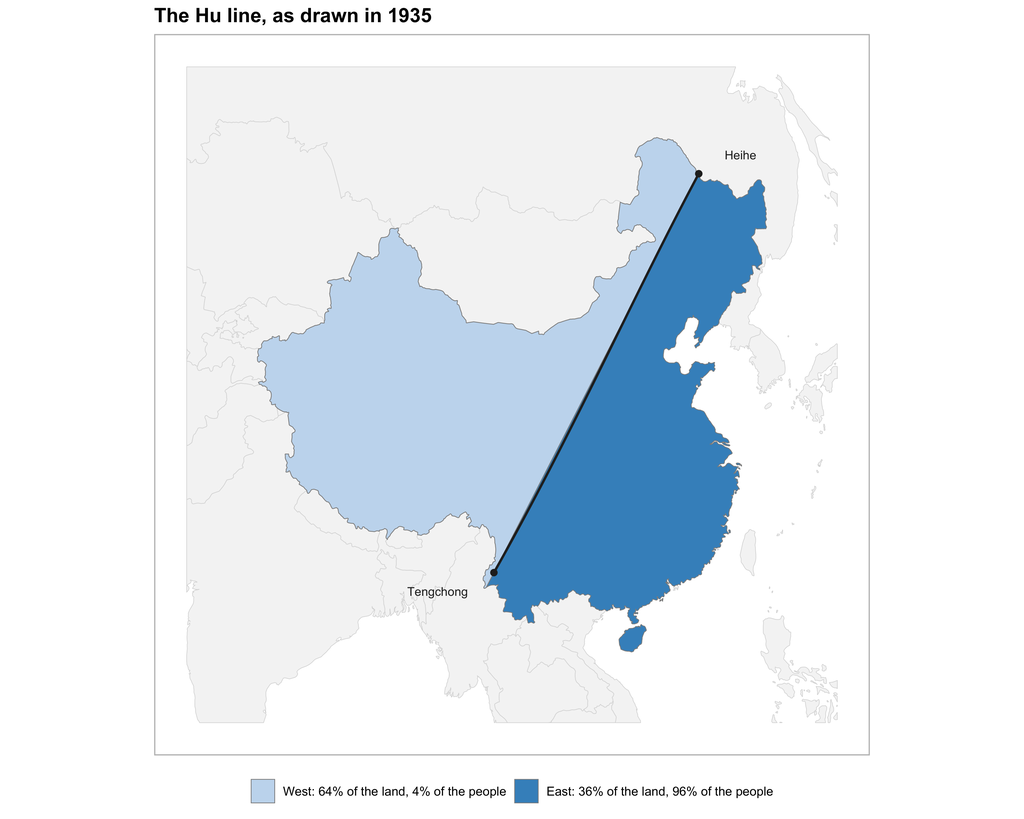

```r
# share of modern Chinese land area falling either side of the line
area_west <- china_sides$area_sh[china_sides$side == "west of the line"]
ggplot() +
  geom_sf(data = cn_neighbors, fill = "grey96", colour = "grey85", linewidth = 0.2) +
  geom_sf(data = china_sides, aes(fill = side), colour = "grey55", linewidth = 0.25) +
  geom_sf(data = hu_line_cn, colour = "grey15", linewidth = 0.8) +
  geom_sf(data = hu_cities, colour = "grey15", size = 1.8) +
  geom_sf_text(data = filter(hu_cities, city == "Heihe"), aes(label = city),
               nudge_x = 2.2e5, nudge_y = 1.6e5, hjust = 0, size = 3, colour = "grey15") +
  geom_sf_text(data = filter(hu_cities, city == "Tengchong"), aes(label = city),
               nudge_x = -2.2e5, nudge_y = -1.6e5, hjust = 1, size = 3, colour = "grey15") +
  scale_fill_manual(
    values = c("west of the line" = "#c6dbef", "east of the line" = "#4292c6"),
    breaks = c("west of the line", "east of the line"),
    labels = c("West: 64% of the land, 4% of the people",
               "East: 36% of the land, 96% of the people"),
    name = NULL) +
  coord_sf(datum = NA) +
  labs(title = "The Hu line, as drawn in 1935") +
  themeClean +
  theme(legend.position = "bottom")
```

Figure 2: The original Hu line.

The shares in the legend are the ones Hu reported in 1935. Recomputing the split on modern boundaries puts 56% of the land west of the line rather than 64%, because the China of 1935 included territory that is no longer within its borders – a reminder that a concentration measure inherits whatever boundary its data carries.

The Hu line can be used to find boundaries that maximize the difference between the high-density coastal population and the lower density inland population; it is also used here to find latitudes and longitudes that divide the country into high-density and low-density portions. Let’s have a look at the Hu line for the U.S. across time.

# 2. Data

All four census files were downloaded from IPUMS NHGIS (nhgis.org), a repository at the University of Minnesota that distributes historical and contemporary U.S. census tables together with matching boundary files. The population tables are the decennial census counts published by the U.S. Census Bureau. The 2020 boundaries are the Census Bureau’s own TIGER/Line files, redistributed by NHGIS. The 1880 boundaries come from the Newberry Library’s *Atlas of Historical County Boundaries*, which NHGIS maintains and distributes; the conflated version used here has been edge-matched to modern TIGER/Line geography so that the two years overlay cleanly. The state file is not an NHGIS product. It was produced once from the 2020 county file by dissolving county boundaries within each state, and then saved locally so that the maps draw quickly. The coastline and the China file are both derived from Natural Earth, and were likewise clipped and saved once so that this document needs no network connection to knit.

## 2.1 Loading the data

The total population column is `AOT001` in 1880 and `U7H001` in 2020; `read_nhgis()` is defined at the top of the chunk below and handles the label row NHGIS inserts under the header.

```r
# NHGIS puts a second header row of variable labels under the column names, so
# the first row of every table is text rather than data. This function reads that
# row as characters and then drops it.
read_nhgis <- function(path) {
  readr::read_csv(path,
                  col_types = cols(.default = "c"),
                  show_col_types = FALSE) %>%
    slice(-1)
}
# Load U.S. county shapefiles
counties_1880 <- st_read(file.path(data_dir, "US_county_1880_conflated.shp"),
                         quiet = TRUE)
counties_2020 <- st_read(file.path(data_dir, "US_county_2020.shp"),
                         quiet = TRUE)
# Load U.S. states shapefile from 2020
states_2020   <- st_read(file.path(data_dir, "US_state_2020.gpkg"),
                         quiet = TRUE)

# That file was made by dissolving the county file, so it kept every county
# boundary vertex -- 5.7 million of them.
states_2020 <- st_simplify(states_2020, preserveTopology = TRUE, dTolerance = 2000)
# Load the CONUS ocean coastline (Natural Earth 10m, Great Lakes excluded)
coastline    <- st_read(file.path(data_dir, "conus_coastline.gpkg"),
                        quiet = TRUE)
# Load U.S. county population data
pop_1880 <- read_nhgis(file.path(data_dir, "1880_county_census.csv")) %>%
  transmute(GISJOIN,
            state = STATE,
            county = COUNTY,
            pop = as.numeric(AOT001))
pop_2020 <- read_nhgis(file.path(data_dir, "2020_county_census.csv")) %>%
  transmute(GISJOIN,
            state = STATE,
            county = COUNTY,
            pop = as.numeric(U7H001))
# Restrict counties to CONUS
# The western territories of 1880 (Dakota, Arizona, Utah, and so on) are kept
non_conus <- c("02", "15", "60", "66", "69", "72", "78")  # AK, HI, AS, GU, MP, PR, VI
counties_2020 <- counties_2020 %>% filter(!STATEFP %in% non_conus)
counties_1880 <- counties_1880 %>% filter(STATENAM != "Alaska Territory")
pop_2020      <- pop_2020      %>% filter(!state %in% c("Alaska", "Hawaii", "Puerto Rico"))
pop_1880      <- pop_1880      %>% filter(state != "Alaska Territory")
```

## 2.2 County population in 1880 and 2020

The population of each county in both years can be seen side-by-side. It is worth looking at the raw distribution before any index is calculated, because everything that follows is an attempt to put a single number on what these two maps show.

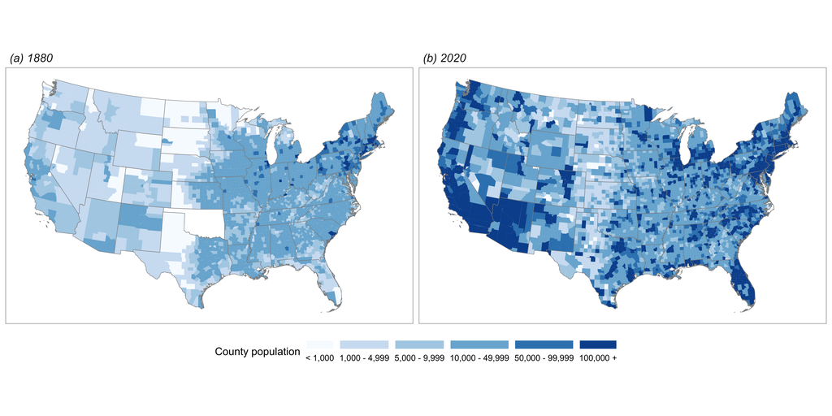

```r
# County population is extremely skewed. A few counties hold millions of people
# while most hold a few thousand, so an unclassed colour ramp would put nearly
# every county in the lightest shade. The map is classed instead, and both years
# share one set of breaks so the same colour means the same number of people.
brk <- c(0, 1e3, 5e3, 1e4, 5e4, 1e5, Inf)
lab <- c("< 1,000", "1,000 - 4,999", "5,000 - 9,999",
         "10,000 - 49,999", "50,000 - 99,999", "100,000 +")
pal <- colorRampPalette(continuous_palette)(length(lab))

# Geometry is simplified for display only
to_choro <- function(shp, pop, yr) {
  shp %>%
    inner_join(select(pop, GISJOIN, pop), by = "GISJOIN") %>%
    st_transform(st_crs(states_2020)) %>%
    st_simplify(preserveTopology = FALSE, dTolerance = 2000) %>%   # 2 km
    mutate(year  = yr,
           class = cut(pop, breaks = brk, labels = lab,
                       include.lowest = TRUE, right = FALSE)) %>%
    select(GISJOIN, pop, year, class)
}
choro <- bind_rows(to_choro(counties_1880, pop_1880, "(a) 1880"),
                   to_choro(counties_2020, pop_2020, "(b) 2020"))

ggplot() +
  geom_sf(data = choro, aes(fill = class), colour = NA) +
  geom_sf(data = states_2020, fill = NA, colour = "grey55", linewidth = 0.2) +
  facet_wrap(~ year) +
  scale_fill_manual(values = pal, drop = FALSE, name = "County population") +
  coord_sf(datum = NA) +
  themeClean +
  theme(legend.position  = "bottom",
        strip.background = element_blank(),
        strip.text       = element_text(size = 12, face = "italic", hjust = 0)) +
  guides(fill = guide_legend(nrow = 1, label.position = "bottom",
                             keyheight = unit(0.35, "cm")))
```

Figure 3: County population in 1880 and 2020, on shared class breaks.

# 3. Results

## 3.1 Distance to the coast and the Hoover index

The Hu line is an instance of the Hoover index and that can be calculated directly once county populations and distances to the coast are known. Here we use Natural Earth’s 10m ocean coastline, clipped to the lower 48 and excludes the Great Lakes. This procedure makes a county in Ohio measures distance to the Atlantic rather than to Lake Erie. We then order Counties by increasing distance from the coast, and **both** the share of total US population and the share of total land area are cumulated along that single ordering. The largest vertical gap between the two cumulative curves is the **Hoover index of concentration**, and the county observed at that breakpoint sets the distance at which the line is drawn (Table 1).

```r
# distance to the nearest coast, and land area, for every county.
# Both are computed in the Albers equal-area projection the files already carry.
coast_u <- coastline %>%
  st_transform(st_crs(counties_2020)) %>%
  st_union()
# CONUS outline, used later to clip the Hu line contours to land
conus <- st_union(states_2020)
coast_stats <- function(shp) {
  shp %>%
    mutate(area_mi2 = as.numeric(st_area(.)) / 2589988) %>%   # m^2 -> square miles
    st_centroid(of_largest_polygon = TRUE) %>%
    mutate(dist_mi = as.numeric(st_distance(., coast_u)) / 1609.34) %>%
    st_drop_geometry() %>%
    select(GISJOIN, area_mi2, dist_mi)
}
pop_1880 <- pop_1880 %>% left_join(coast_stats(counties_1880), by = "GISJOIN")
pop_2020 <- pop_2020 %>% left_join(coast_stats(counties_2020), by = "GISJOIN")

# counties ordered by distance to coast, with population and area cumulated
lorenz_table <- function(d, yr) {
  d %>%
    filter(!is.na(pop), pop > 0, !is.na(dist_mi), !is.na(area_mi2)) %>%
    arrange(dist_mi) %>%                       # counties, nearest the coast first
    mutate(rank     = row_number(),            # position in that ordering
           cum_pop  = cumsum(pop)      / sum(pop),   # share of total US population
           cum_area = cumsum(area_mi2) / sum(area_mi2), # share of total land area
           gap      = cum_pop - cum_area,
           year     = yr)
}
lorenz_1880 <- lorenz_table(pop_1880, "1880")
lorenz_2020 <- lorenz_table(pop_2020, "2020")
# the Hoover index is the largest vertical gap; that row sets the Hu line
hu <- bind_rows(lorenz_1880, lorenz_2020) %>%
  group_by(year) %>%
  slice_max(gap, n = 1, with_ties = FALSE) %>%
  ungroup() %>%
  select(year, hoover = gap, cut_mi = dist_mi, cum_pop, cum_area)
kable(hu, digits = 4) %>%
  kable_styling(full_width = T)
```

| year | hoover | cut_mi | cum_pop | cum_area |
| --- | --- | --- | --- | --- |
| 1880 | 0.189 | 268.2 | 0.564 | 0.375 |
| 2020 | 0.306 | 56.8 | 0.414 | 0.108 |

Table 1: The Hoover index for each year, the distance inland at which it occurs, and the share of population and land area seaward of that line.

The Hoover indices for 1880 and 2020 can be visualized using the Lorenz curve.

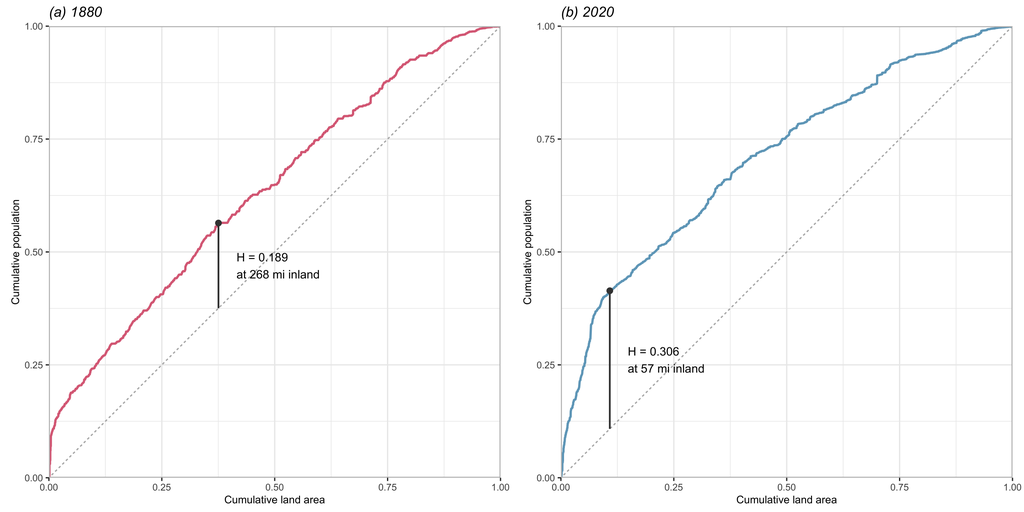

```r
col_year <- c(`1880` = "#DC6D85", `2020` = "#6EA6C3")

lor_panel <- function(l, lab) {
  yr <- unique(l$year)
  h  <- filter(hu, year == yr)
  ggplot(l, aes(cum_area, cum_pop)) +
    geom_abline(slope = 1, intercept = 0, colour = "grey70", linetype = "22") +
    geom_path(colour = col_year[[yr]], linewidth = 0.9) +   # path, not line: follow the distance ordering
    geom_segment(data = h,
                 aes(x = cum_area, xend = cum_area, y = cum_area, yend = cum_pop),
                 colour = "grey25", linewidth = 0.7) +
    geom_point(data = h, aes(cum_area, cum_pop), colour = "grey25", size = 2) +
    annotate("text", x = h$cum_area + 0.04, y = (h$cum_area + h$cum_pop) / 2,
             hjust = 0, size = 3.5,
             label = sprintf("H = %.3f\nat %.0f mi inland", h$hoover, h$cut_mi)) +
    scale_x_continuous(limits = c(0, 1), expand = c(0, 0)) +
    scale_y_continuous(limits = c(0, 1), expand = c(0, 0)) +
    coord_equal() +
    labs(subtitle = lab,
         x = "Cumulative land area", y = "Cumulative population") +
    themeGrid +
    theme(axis.title = element_text(size = 9))
}
grid.arrange(lor_panel(lorenz_1880, "(a) 1880"),
             lor_panel(lorenz_2020, "(b) 2020"), ncol = 2)
```

Figure 4: Lorenz curves of population against land area, with counties ordered from the coast inland.

The vertical segment marks the Hoover index – the largest gap between the curve and the line of even density.

We can use this distance to map the ‘Hu line’ along the U.S. coasts for an alternative visualization. Specifically, we map the points that far from the ocean. Buffering the coastline by that distance and keeping the landward edge draws the line. We can immediately see that the U.S. Hu line appears to be nearer to the coasts in 2020, but how stable is that result?

```r
mk_line <- function(yr) {
  d <- hu$cut_mi[hu$year == yr]
  g <- coast_u %>%
    st_buffer(d * 1609.34) %>%
    st_boundary() %>%
    st_intersection(conus)
  st_sf(year = yr, cut_mi = d, geometry = st_geometry(g))
}
hu_lines <- bind_rows(mk_line("1880"), mk_line("2020"))

ggplot() +
  geom_sf(data = states_2020, fill = "grey97", colour = "grey80", linewidth = 0.25) +
  geom_sf(data = hu_lines, aes(colour = year), linewidth = 0.7) +
  scale_colour_manual(values = col_year, name = NULL) +
  coord_sf(datum = NA) +
  labs(title = "US Hu lines, 1880 and 2020",
       subtitle = sprintf("Each line marks the distance inland at which the Hoover index peaks: %.0f mi in 1880, %.0f mi in 2020.",
                          hu$cut_mi[hu$year == "1880"], hu$cut_mi[hu$year == "2020"])) +
  themeClean +
  theme(legend.position = "bottom")
```

[figure not shown]

Figure 5: The Hu line is a distance-to-coast contour, not a straight diagonal.

Seaward of the 2020 line lies a small share of the land area and a large share of the people.

## 3.2 How sharp is that peak?

### 3.2.1 The 2020 U.S. Hu Line

```r
tol <- 0.015   # how close to the peak counts as "tied"
```

We begin by plotting distance to the coast against the Hoover index values of each county for the year 2020. We allow for a bandwidth of 0.015 off the peak Hoover index to capture counties close to the peak.

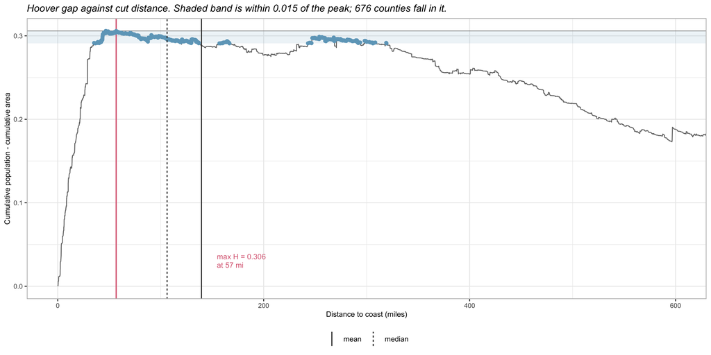

```r
peak      <- max(lorenz_2020$gap)
near_peak <- lorenz_2020 %>% filter(gap >= peak - tol)
stat_lines <- tibble(
  stat  = c("mean", "median"),
  value = c(mean(near_peak$dist_mi), median(near_peak$dist_mi)))
# the cut distance at which the gap is largest -- the maximum Hoover index
d_peak <- lorenz_2020$dist_mi[which.max(lorenz_2020$gap)]
# park the label clear of the mean/median lines, and inside the panel
lab_x <- max(c(d_peak, stat_lines$value)) + 15
lab_h <- 0
if (lab_x > 500) { lab_x <- min(c(d_peak, stat_lines$value)) - 15; lab_h <- 1 }
# the Hoover gap is a function of the cut distance -- plot the whole function,
# not just the slice of it that clears a threshold
ggplot(lorenz_2020, aes(dist_mi, gap)) +
  annotate("rect", xmin = -Inf, xmax = Inf, ymin = peak - tol, ymax = peak,
           fill = "#6EA6C3", alpha = 0.12) +
  geom_hline(yintercept = peak, colour = "grey55", linewidth = 0.4) +
  geom_path(colour = "grey45", linewidth = 0.5) +
  # the maximum itself
  geom_vline(xintercept = d_peak, colour = "#DC6D85", linewidth = 0.7) +
  annotate("text", x = lab_x,
           y = min(lorenz_2020$gap) + 0.10 * diff(range(lorenz_2020$gap)),
           hjust = lab_h, size = 3.2, colour = "#DC6D85", lineheight = 0.95,
           label = sprintf("max H = %.3f\nat %.0f mi", peak, d_peak)) +
  geom_point(data = near_peak, aes(dist_mi, gap),
             colour = "#6EA6C3", size = 1.6) +
  geom_vline(data = stat_lines, aes(xintercept = value, linetype = stat),
             colour = "grey20", linewidth = 0.6) +
  scale_linetype_manual(values = c(mean = "solid", median = "22"), name = NULL) +
  coord_cartesian(xlim = c(0, 600)) +
  labs(subtitle = sprintf("Hoover gap against cut distance. Shaded band is within %.3f of the peak; %d counties fall in it.",
                          tol, nrow(near_peak)),
       x = "Distance to coast (miles)", y = "Cumulative population - cumulative area") +
  themeGrid +
  theme(axis.title = element_text(size = 9), legend.position = "bottom")
```

Figure 6: The Hoover gap as a function of how far inland the line is drawn. Points mark counties within 0.015 of the peak; the vertical lines are the mean (solid) and median (dashed) of their distances.

The red line marks the maximum: the Hoover index peaks at 0.306 when the line is drawn 57 miles inland. Taken alone that looks like a precise answer, but the shape of the curve around it says otherwise. The shaded band covers every cut distance whose index comes within 0.015 of the peak, and 676 counties fall inside it. Those counties are not clustered around the red line: the mean of their distances is 140 miles and the median is 106 miles, both well inland of the maximum. The curve also rises a second time roughly 200 miles further inland, coming within 0.007 of the best value in the entire series. Two lines drawn 200 miles apart therefore divide the country almost equally well, and the index has no strong preference between them. The *value* of the index is well determined; the *distance* that produces it is not, and the consequences of that are easiest to see on a map.

```r
# --- three candidate cut distances -------------------------------------------
d_max  <- lorenz_2020$dist_mi[which.max(lorenz_2020$gap)]
d_mean <- mean(near_peak$dist_mi)
d_near <- lorenz_2020 %>% filter(dist_mi <= 100) %>%
  slice_max(gap, n = 1, with_ties = FALSE) %>% pull(dist_mi)
cuts <- tibble(
  which  = factor(c("Maximum", "Plateau mean", "Best within 100 mi"),
                  levels = c("Maximum", "Plateau mean", "Best within 100 mi")),
  cut_mi = c(d_max, d_mean, d_near)) %>%
  rowwise() %>%
  mutate(cum_area = lorenz_2020$cum_area[which.min(abs(lorenz_2020$dist_mi - cut_mi))],
         cum_pop  = lorenz_2020$cum_pop [which.min(abs(lorenz_2020$dist_mi - cut_mi))]) %>%
  ungroup() %>%
  mutate(gap   = cum_pop - cum_area,
         label = sprintf("H = %.3f\n%.0f mi", gap, cut_mi))
col_cut <- c(`Maximum` = "#6EA6C3", `Plateau mean` = "#DC6D85",
             `Best within 100 mi` = "#FFD190")

# --- (a) the curve, with each candidate marked -------------------------------
p_curve <- ggplot(lorenz_2020, aes(cum_area, cum_pop)) +
  geom_abline(slope = 1, intercept = 0, colour = "grey70", linetype = "22") +
  # guide lines: down to the x-axis, and across to the y-axis
  geom_segment(data = cuts,
               aes(x = cum_area, xend = cum_area, y = 0, yend = cum_area, colour = which),
               linetype = "22", linewidth = 0.4, alpha = 0.6) +
  geom_segment(data = cuts,
               aes(x = 0, xend = cum_area, y = cum_pop, yend = cum_pop, colour = which),
               linetype = "22", linewidth = 0.4, alpha = 0.6) +
  geom_path(colour = "grey45", linewidth = 0.8) +
  # the Hoover gap itself: diagonal up to the curve
  geom_segment(data = cuts,
               aes(x = cum_area, xend = cum_area, y = cum_area, yend = cum_pop,
                   colour = which), linewidth = 1) +
  geom_point(data = cuts, aes(cum_area, cum_pop, colour = which), size = 2.2) +
  geom_text(data = cuts,
            aes(x = cum_area + 0.025, y = (cum_area + cum_pop) / 2,
                label = label, colour = which),
            hjust = 0, size = 3, lineheight = 0.95, show.legend = FALSE) +
  scale_colour_manual(values = col_cut, name = NULL) +
  scale_x_continuous(limits = c(0, 1), expand = c(0, 0)) +
  scale_y_continuous(limits = c(0, 1), expand = c(0, 0)) +
  coord_equal() +
  labs(subtitle = "(a) Where each candidate sits on the curve",
       x = "Cumulative land area", y = "Cumulative population") +
  themeGrid +
  theme(axis.title = element_text(size = 9), legend.position = "bottom")

# --- (b) the same three cuts as contours on the map --------------------------
hu_contour <- function(d_mi, label) {
  g <- coast_u %>%
    st_buffer(d_mi * 1609.34) %>%
    st_boundary() %>%
    st_intersection(conus)
  st_sf(which = label, cut_mi = d_mi, geometry = st_geometry(g))
}
contours <- bind_rows(lapply(seq_len(nrow(cuts)),
                             function(i) hu_contour(cuts$cut_mi[i], as.character(cuts$which[i])))) %>%
  mutate(which = factor(which, levels = levels(cuts$which)))
# label each contour where it passes nearest a fixed anchor. Move the anchor if
# the labels collide -- the three lines are well separated north of the Gulf.
anchor <- st_sfc(st_point(c(-97, 45)), crs = 4326) %>% st_transform(st_crs(contours))
lab_pts <- bind_rows(lapply(seq_len(nrow(contours)), function(i) {
  p <- st_nearest_points(anchor, st_geometry(contours)[i]) %>% st_cast("POINT")
  st_sf(which  = contours$which[i],
        cut_mi = contours$cut_mi[i],
        geometry = p[2])                       # p[1] is the anchor, p[2] is on the line
})) %>%
  mutate(which = factor(which, levels = levels(cuts$which)))
p_map <- ggplot() +
  geom_sf(data = states_2020, fill = "grey97", colour = "grey80", linewidth = 0.25) +
  geom_sf(data = contours, aes(colour = which), linewidth = 0.7) +
  geom_sf_label(data = lab_pts,
                aes(label = sprintf("%.0f mi", cut_mi), colour = which),
                fill = "white", label.size = 0, label.padding = unit(0.12, "lines"),
                size = 3, fontface = "bold", show.legend = FALSE) +
  scale_colour_manual(values = col_cut, name = NULL) +
  coord_sf(datum = NA) +
  labs(subtitle = sprintf("(b) %.0f mi, %.0f mi, and %.0f mi inland",
                          d_max, d_mean, d_near)) +
  themeClean +
  theme(legend.position = "bottom")
grid.arrange(p_curve, p_map, ncol = 2, widths = c(1, 1.25))
```

[figure not shown]

Figure 7: (a) Three candidate rules applied to the same Hoover index, spanning just 0.017 of index value. Because the maximum already falls within 100 miles of the coast, two of the rules select the same distance, so (b) draws two contours rather than three. The index barely distinguishes the choices; the map does.

Because the overall maximum already lies within 100 miles of the coast, two of the three rules select the same distance in 2020, so panel (b) draws two distinct contours rather than three. The one that differs is the plateau mean, and it moves the line 83 miles inland while costing only 0.017 in index value. On the index that difference is almost invisible; on the map it is the difference between a line hugging the coastal counties and one running well into the interior. Which of these is the U.S. Hu line depends on a choice the index itself cannot make for us.

### 3.2.2 The 1880 U.S. Hu Line

Running the identical diagnostic on 1880 can be used as a control and diagnostic test. If the plateau is an artifact of the method it should appear in both; if it is a feature of the modern settlement pattern it should not.

[figure not shown]

Figure 8: The same diagnostic applied to 1880. The gap curve rises to a single peak and falls away, so the maximum is well identified and the three candidates are not interchangeable – which is exactly what 2020 fails to show.

Notice that the 1880 curve rises to a single peak and then falls away from it. The red line marking the maximum, the solid mean line, and the dashed median line all sit within about 8 miles of one another, so every reasonable summary of the plateau points to the same distance. Only 286 counties fall within 0.015 of the 1880 peak, against 676 in 2020. Moving the line away from that peak also costs something measurable: across the three candidate cuts the index varies by 0.031 in 1880, so the data themselves can tell us which choice is the better one. Compare that to 2020, where the plateau mean and median sit roughly 83 and 49 miles inland of the maximum, and where a second rise a few hundred miles further inland comes within 0.007 of the best value in the entire series.

# 4. Summary

This demonstration asked whether the United States has an equivalent of the Hu line, and if so, where it runs. Answering that required three ideas in sequence. The Lorenz curve gave us a way to plot cumulative population against cumulative land area, the Hoover index gave us a single number for the gap between that curve and even density, and ordering counties by distance to the coast turned the index into a line we could actually draw.

The answer is that a U.S. Hu line exists and has moved sharply toward the coast. In 1880 the index peaked 268 miles inland, where 56% of the population lived on 38% of the land. By 2020 it peaked just 57 miles inland, with 41% of the population on 11% of the land, and the index itself rose from 0.189 to 0.306. The country is markedly more concentrated than it was, and that concentration is coastal.

The diagnostic in Section 3.2 is the part worth carrying forward. The 2020 index is flat near its maximum, so 676 counties are statistically tied for setting the line and candidate distances 83 miles apart score almost identically. Running the same procedure on 1880 showed a single sharp peak, which tells us the plateau is a property of the 2020 settlement pattern rather than an artifact of the Hoover index or of the county data we fed it. In 1880 the settled population formed a single band that thinned out steadily inland, and one distance divided the country better than any other. By 2020 the coast holds one concentration of people and the interior holds another, and the index is very nearly indifferent between drawing the line at either.

Two cautions apply to everything above. First, the value we report is the concentration achieved by ordering counties on distance to the coast; it is not the maximum attainable Hoover index, which a different ordering could raise. Second, the result inherits every boundary decision made upstream – excluding the Great Lakes, restricting to the lower 48, assigning each county its centroid – just as Hu’s original 64% depended on the borders China had in 1935. This is worth remembering whenever a single statistic is asked to locate something on a map: a well-determined *value* does not guarantee a well-determined *place*.

### Declaration of Generative AI and AI-Assisted Technologies

The author used Anthropic’s Claude (Opus 5) when developing this demonstration. A connection to RStudio through the ClaudeR package, was used to draft and debug the R code. The author subsequently reviewed and edited all of that output and takes full responsibility for the content.